# Normalization for age variable

kithsiri Jayakody

11/9/2020

As the first step in here, I’m going to load the data to the R envirnment.

```r
setwd('D:/statistics')
# dataset is loading and converting the character based data types to factors
df = read.csv('sperformance-dataset.csv',stringsAsFactors = F)

# converting the character type into factorial variables and see the conversion
indices <- c(1,2,4:6,9:14,18:23,34,38:43)

for(i in indices)
{
  df[[i]] <- as.factor(df[[i]])
}
```

After loading the dataset following codeblock will install all the relavant libraries. Moreover allthe column names convert into simple before it runs.

```r
#Setting the column names to be that used in the dataset but in lowercase to make life a bit easier
colnames(df) <- tolower(colnames(df))
#Remember to install these packages if you haven't already done so

#First check that package required is installed, if not install it
# Specify your packages
needed_packages <- c("pastecs", "ggplot2", "semTools", "FSA")
# Extract not installed packages
not_installed <- needed_packages[!(needed_packages %in% installed.packages()[ , "Package"])]
# Install not installed packages
if(length(not_installed)) install.packages(not_installed)



library(pastecs) #For creating descriptive statistic summaries
library(ggplot2) #For creating histograms with more detail than plot
library(semTools) #For skewness and kurtosis
```

Checking the normalization of the age scalar variable.

# Check the Normality for the age Variable

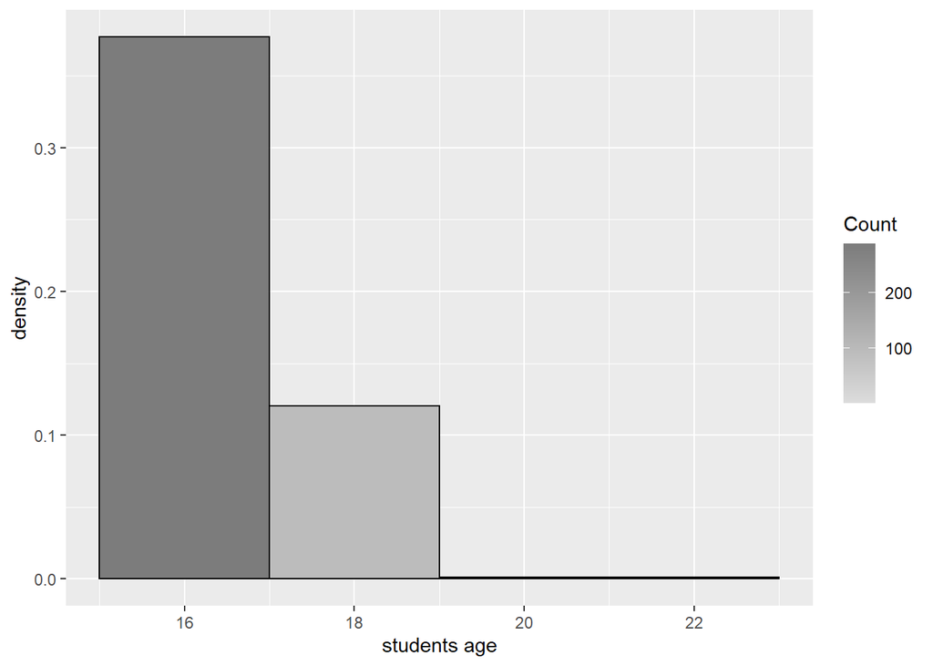

```r
#this line is using the ggplot package to create the historgram. df represents the dataset and the
# x= age represent the scal variable

gg <- ggplot(df, aes(x=age))

#Change the label of the x axis student age
gg <- gg + labs(x="students age")

#following code generate the histogram for age with bandwidth=2

gg <- gg + geom_histogram(binwidth=2, colour="black", aes(y=..density.., fill=..count..))
gg <- gg + scale_fill_gradient("Count", low="#DCDCDC", high="#7C7C7C")
gg
```

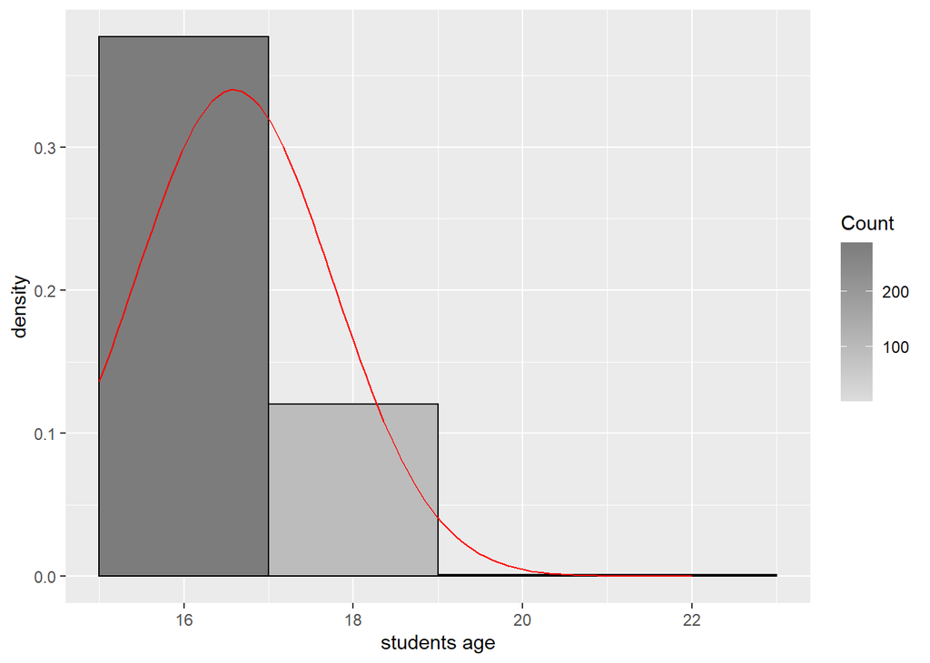

```r
#adding a normal curve
#use stat_function to compute a normalised score for each value of age
#pass the mean and standard deviation of the age variable
#use the na.rm parameter to say how missing values are handled
gg <- gg + stat_function(fun=dnorm, color="red",args=list(mean=mean(df$age, na.rm=TRUE), sd=sd(df$age, na.rm=TRUE)))

#to display the graph request the contents of the variable be shown acording to the age
gg
```

then we generate the Q-Q plot for the age variable to check normal distribution visually

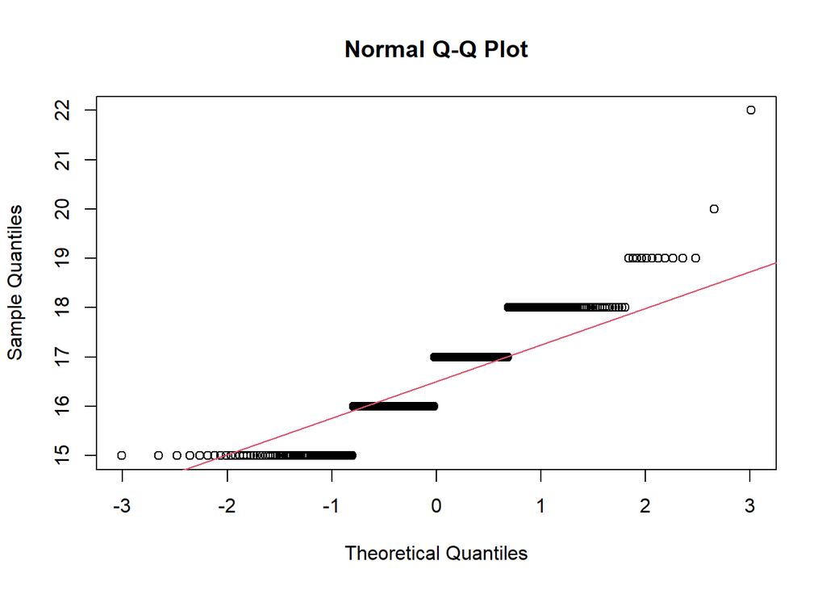

```r
#Create a qqplot for the age column
qqnorm(df$age)
qqline(df$age, col=2) #show a line on the plot
```

by oberving the output of the Q-Q plot and the histogram it seems like it does not follow normal distribution. further with the following function I’m looking for summary statistic for the same variable age

```r
#stat.desc is a function from pastecs to test the summary statistics of the age column
pastecs::stat.desc(df$age, basic=F)
```

```
##       median         mean      SE.mean CI.mean.0.95          var      std.dev
##  17.00000000  16.58638743   0.06003995   0.11805115   1.37703206   1.17347009
##     coef.var
##   0.07074899
```

even though it seems lik skew, we are going to calculate Standardized skewness and kurtosis and the Percentage of standardized scores falling within acceptable ranges as the first step we are going to calcuate the Standardized skewness and kurtosis.Standardised scores (value/std.error) for skewness between +/-2 (1.96 rounded) are considered acceptable in order to prove normal univariate distribution.

```r
#We can make our decision based on the value of the standardised score for skew and kurtosis for age
# variable
#We divide the skew statistic by the standard error to get the standardised score
#This will indicate if we have a problem
tpskew<-semTools::skew(df$age)
tpkurt<-semTools::kurtosis(df$age)
tpskew[1]/tpskew[2]
```

```
## skew (g1)
##  3.179405
```

```r
tpkurt[1]/tpkurt[2]
```

```
## Excess Kur (g2)
##       0.3905659
```

as shown with the above result it seems that kurosis comes with in the acceptable range but the skewness is not with in the acceptable range. therefore here with I’m going to calculate the Percentage of standardized scores falling within acceptable ranges.

```r
#and by calculating the percentage of standardised scores for the variable itself that are outside our acceptable range
#This will tell us how big a problem we have
# Calculate the percentage of standardised scores that are greated than 1.96
# the perc function which is part of the FSA package which calculate the percentage that are within a range -
#you can look for greater than "gt", greater than or equal "geq", "gt", less than or equal "leq",  or less than "lt"),
# scale is a function that creates z scores, abs gets absolute value

df_age<- abs(scale(df$age))

FSA::perc(as.numeric(df_age), 1.96, "gt")
```

```
## [1] 3.403141
```

```r
FSA::perc(as.numeric(df_age), 3.29, "gt")
```

```
## [1] 0.2617801
```